# ISP Final Project

Annika Kufrovich

January 18, 2019

## Function quick look

Test Dataframes

```r
test1b <- data.frame(numbers = 1:8, letters = c("a", "b", "c", "d", "a", "b", "c", "d"))
test4b <- data.frame(numbers = 1:8, letters = c("a", "b", "c", "d", "a", "b", "c", "e"), lon = c(12, 31, 64, 38, 89, 73, 91, 21))
```

Function

```r
matching_dfs_addcol <- function(newdf, olddf) {
  matching <- semi_join(olddf, newdf)
  matching_col <- matching %>%
    mutate(matched = TRUE)
  not_matching <- anti_join(newdf, olddf)
  not_matching_col <- not_matching %>%
    mutate(matched = FALSE)
  combined_df <- full_join(matching_col, not_matching_col)
  combined_df
}

new_func_test <- matching_dfs_addcol(test1b, test4b)
new_func_test
```

```
##   numbers letters lon matched
## 1       1       a  12    TRUE
## 2       2       b  31    TRUE
## 3       3       c  64    TRUE
## 4       4       d  38    TRUE
## 5       5       a  89    TRUE
## 6       6       b  73    TRUE
## 7       7       c  91    TRUE
## 8       8       d  NA   FALSE
```

## Geocoding

```r
new_lib <- read.delim("C:/Users/TeenieTiny/Desktop/2nd Year/Data/Voter_Registration_20181113/20181113_VoterDetail/LIB_20181113.txt", header=FALSE)



#this didn't work with mutate_geocode, alternatives with commas didn't help
#new_lib_addres <- new_lib %>%
#  mutate(address = paste(V8, V10, V12, sep = " "))


#thought this would fix it, it didn't, alternatives with commas didn't help
#new_lib_addres <- new_lib %>%
#  mutate(address = paste(V8, V10, V12, sep = ", "), stringsAsFactors = FALSE)


new_lib_addres <- new_lib %>%
  mutate(address = paste(V8, V10, "FL", sep = ", "))
```

```r
#geocoding first 1000 obs
nl_p1 <- new_lib_addres %>%
  slice(1:1000)

nl_geocode_p1 <- nl_p1 %>%
  mutate_geocode(address, source = "dsk")


#2nd 1000 obs
nl_p2 <- new_lib_addres %>%
  slice(1001:2000)

nl_geocode_p2 <- nl_p2 %>%
  mutate_geocode(address, source = "dsk")


#3rd 1000 obs
nl_p3 <- new_lib_addres %>%
  slice(2001:3000)

nl_geocode_p3 <- nl_p3 %>%
  mutate_geocode(address, source = "dsk")


#4th 1000 obs
nl_p4 <- new_lib_addres %>%
  slice(3001:4000)

nl_geocode_p4 <- nl_p4 %>%
  mutate_geocode(address, source = "dsk")


#
nl_p5 <- new_lib_addres %>%
  slice(4001:4626)

nl_geocode_p5 <- nl_p5 %>%
  mutate_geocode(address, source = "dsk")



#I should have made a function, making this one and will test if it works later
geocoding <- function(df, address_col, seq) {
  sliced <- df %>%
    slice(seq)
  geocoded <- sliced %>%
    mutate_geocode(address_col, source = "dsk")
  geocoded
}


#joining all geocoded datasets
nl_join <- full_join(nl_geocode_p5,
                     full_join(nl_geocode_p4,
                               full_join(nl_geocode_p3,
                                         full_join(nl_geocode_p1, nl_geocode_p2))))
nl_join <- nl_join %>%
  filter(!is.na(lon)) %>%
  filter(!is.na(lat))
```

## Getting shape of liberty county

```r
#retrieving sp object in case sf object doesn't behave
options(tigris_class = "sp")
fl_counties <- counties(state = "FL")
```

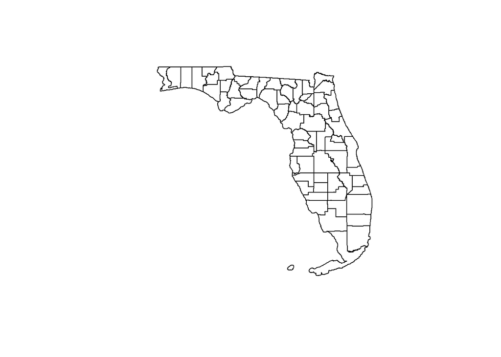

```r
plot(fl_counties)
```

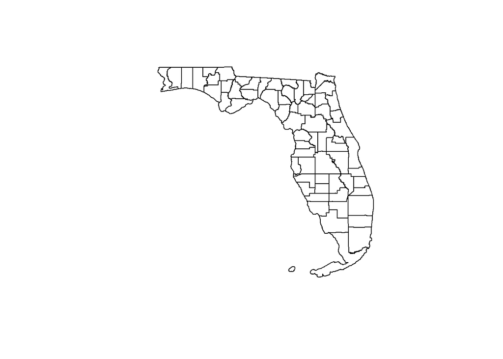

```r
#retrieving sf object because it will probably be easier to isolate liberty county this way
options(tigris_class = "sf")
fl_counties2 <- counties(state = "FL")
plot(fl_counties2$geometry)
```

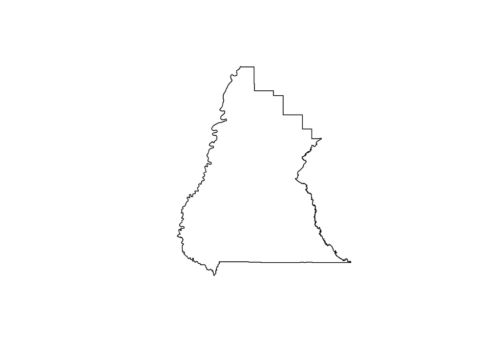

```r
#isolating liberty county
liberty <- fl_counties2 %>%
  filter(NAME == "Liberty")
plot(liberty$geometry)
```

Now that we have the geometry, let’s check if things match up

```r
liberty$geometry
```

```
## Geometry set for 1 feature
## geometry type:  MULTIPOLYGON
## dimension:      XY
## bbox:           xmin: -85.15402 ymin: 29.9714 xmax: -84.54287 ymax: 30.60639
## epsg (SRID):    4269
## proj4string:    +proj=longlat +datum=NAD83 +no_defs
```

```
## MULTIPOLYGON (((-84.78179 30.51673, -84.78177 3...
```

```r
min(nl_join$lon)
```

```
## [1] -85.08899
```

```r
max(nl_join$lon)
```

```
## [1] -82.5001
```

```r
max(nl_join$lat)
```

```
## [1] 30.65978
```

```r
min(nl_join$lat)
```

```
## [1] 28.75054
```

the mins and max’s don’t match, before I try to narrow this down, lets see what happens if I try to put my data and geometry in to a ppp object

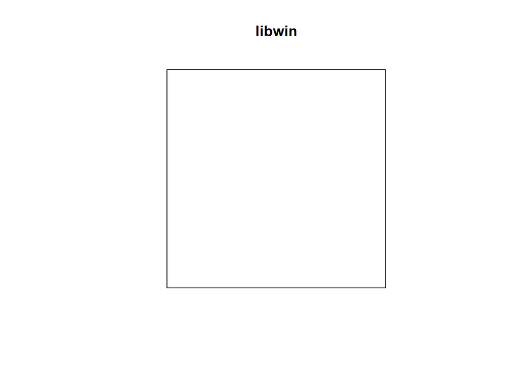

```r
#making my window
libwin <- owin(xy = liberty$geometry)
plot(libwin)
```

```r
summary(libwin)
```

```
## Window: rectangle = [0, 1] x [0, 1] units
## Window area = 1 square unit
```

```r
#this didn't come out the way I expected it to, just made a square ranging from 0 to 1 on each axis
#may come back to this




#transforming lat/lon coordinates to x/y coordinates and reducing to 0-1 scale
nl_jxy <- nl_join %>%
  mutate(y = lon, x = lat)

nl_min <- nl_jxy %>%
  select(x, y, V29, V24)

minx <- min(nl_min$x, na.rm = TRUE)
maxx <- max(nl_min$x, na.rm = TRUE)

nl_min$x <- (nl_min$x - minx)/(maxx - minx)

miny <- min(nl_min$y, na.rm = TRUE)
maxy <- max(nl_min$y, na.rm = TRUE)

nl_min$y <- (nl_min$y - miny)/(maxy - miny)



#Making unmarked ppp object

libppp <- ppp(nl_min$x, nl_min$y, window = libwin)

#ppp object marked by voter status (Active vs Inactive)
libppp_act <- ppp(nl_min$x, nl_min$y, window = libwin, marks = nl_min$V29)



#Making party variable
#may change this to case_when rather than ifelse later
summary(nl_min$V24)
```

```
##  CPF  DEM  GRE  LPF  NPA  REF  REP
##    1 3197    1    2  438    1  983
```

```r
nl_min <- nl_min %>%
  mutate(party = ifelse(V24 == "DEM", "Democrat",
                        ifelse(V24 == "REP", "Republican", "NPA/Other")))
nl_min$party <- as.factor(nl_min$party)

#ppp marked by party
libppp_party <- ppp(nl_min$x, nl_min$y, window = libwin, marks = nl_min$party)
```

## Tests and Plots

Really quick, lets look at a basic plot of registered voters in Liberty county

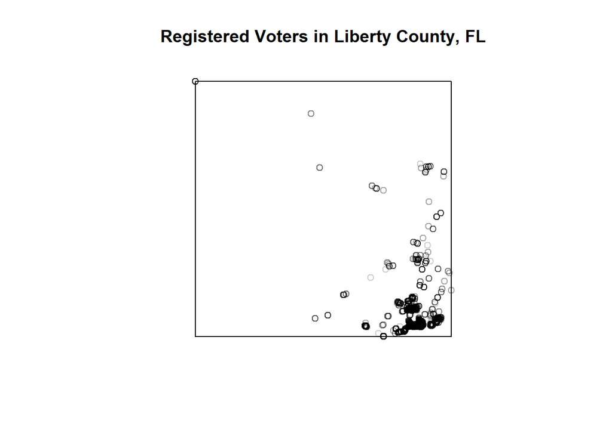

```r
plot(libppp, main = "Registered Voters in Liberty County, FL")
```

Looking at spatial dispersion of all registered voters in liberty county regardless of active status or party affiliation. I expect that the quadrat test will show that there is clustering.

```r
quad_lib <- quadrat.test(libppp, alternative = "clustered")
quad_lib
```

```
##
##  Chi-squared test of CSR using quadrat counts
##  Pearson X2 statistic
##
## data:  libppp
## X2 = 79569, df = 24, p-value < 2.2e-16
## alternative hypothesis: clustered
##
## Quadrats: 5 by 5 grid of tiles
```

Some alternatives to the quadrat test are the nearest neighbor test and the G function to check for spatial randomness.

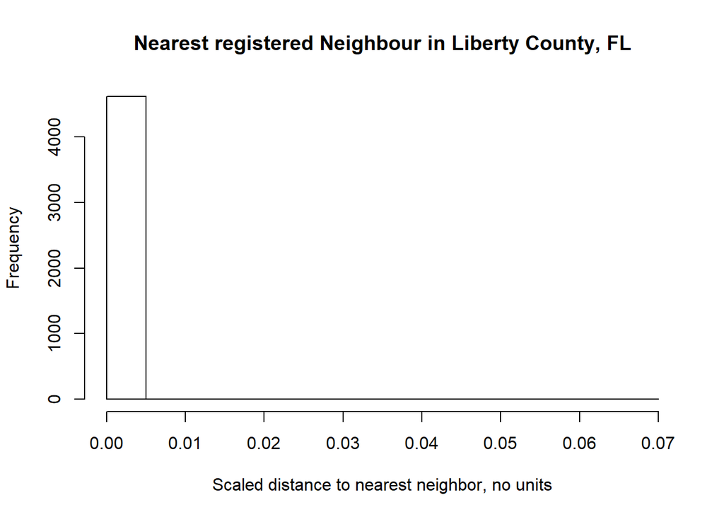

```r
nnd_lib <- nndist(libppp)
hist(nnd_lib, xlab = "Scaled distance to nearest neighbor, no units",
     main = "Nearest registered Neighbour in Liberty County, FL")
```

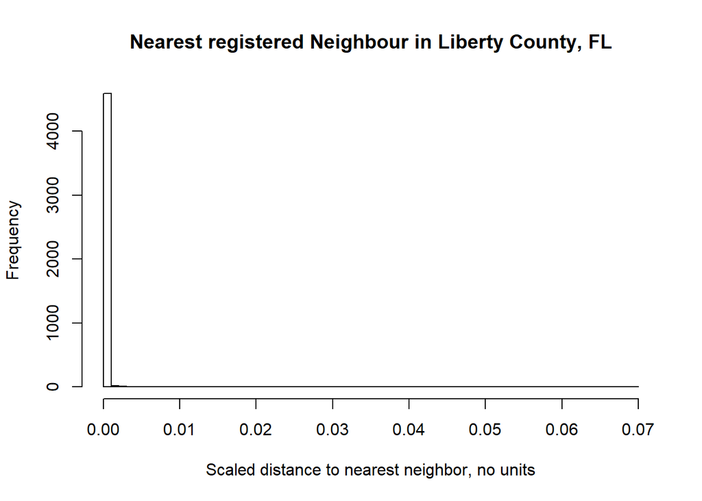

```r
#this isn't super helpful, lets try adding breaks
brks <- seq(0, 0.07, by = 0.001)

hist(nnd_lib, breaks = brks, xlab = "Scaled distance to nearest neighbor, no units",
     main = "Nearest registered Neighbour in Liberty County, FL")
```

[figure not shown]

```r
#Doesn't make our distribution easier to see, jutst proves this is a right skewed
#distribution since only a couple people are not in close proximity to others


#not sure why this isn't working properly
gest_lib <- Gest(libppp)
plot(gest_lib)
```

We can see from the distribution of our nearest neighbour distance test that most regitered voters are in some kind of close proximity to other registered voters in liberty county. We are still unable to conclude whether this is specific to registered voters as this could simply be because all people in liberty county cluster similarly whether or not they are registered.

Let’s look at some density plots

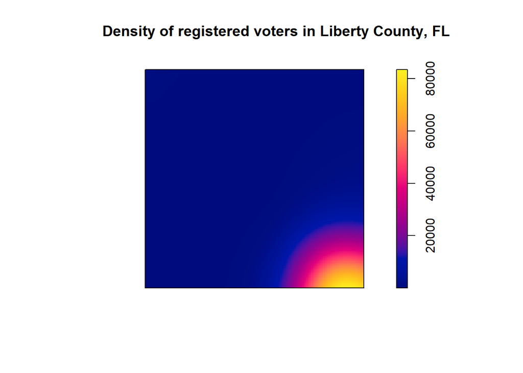

```r
#general density
gen_dens <- plot(density(libppp), main = "Density of registered voters in Liberty County, FL")
```

```r
gen_dens
```

[output not shown]

[output cut: 243 more lines]

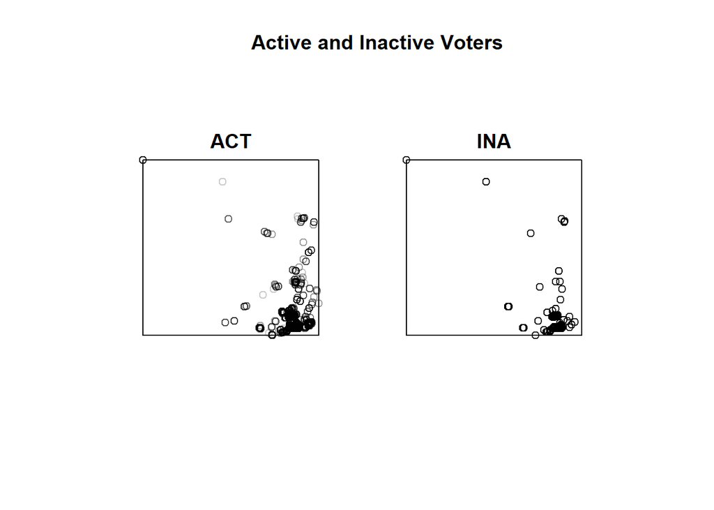

```r
#basic and density plots of active and inactive voters
active_splits <- split(libppp_act)
bas_act <- plot(active_splits, main = "Active and Inactive Voters")
```

```r
bas_act
```

```
## [[1]]
## Symbol map with constant values
## cols: #00000036
##
## [[2]]
## Symbol map with constant values
## cols: #000000E0
```

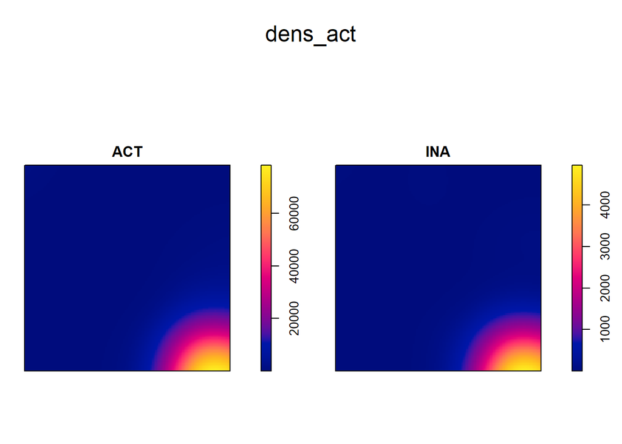

```r
dens_act <- density(active_splits)
plot(dens_act)
```

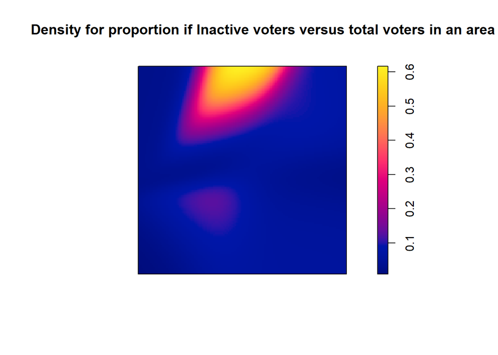

```r
#looking for where inactive voters are more prominent
frac_dens_act <- dens_act[[2]] / (dens_act[[1]] + dens_act[[2]])

plot(frac_dens_act, main = "Density for proportion if Inactive voters versus total voters in an area")
```

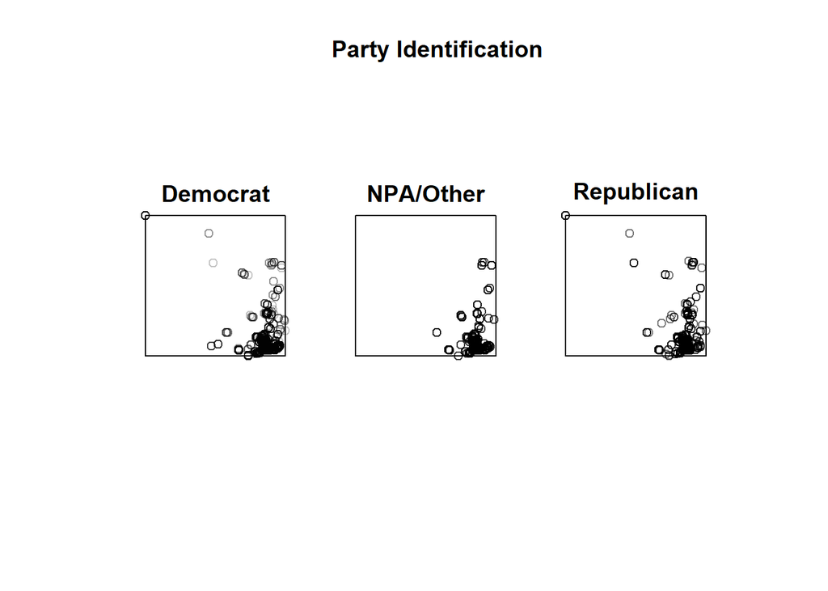

```r
#looking at party distribution/density
party_splits <- split(libppp_party)
bas_party <- plot(party_splits, main = "Party Identification")
```

```r
bas_party
```

```
## [[1]]
## Symbol map with constant values
## cols: #0000003C
##
## [[2]]
## Symbol map with constant values
## cols: #000000C4
##
## [[3]]
## Symbol map with constant values
## cols: #00000087
```

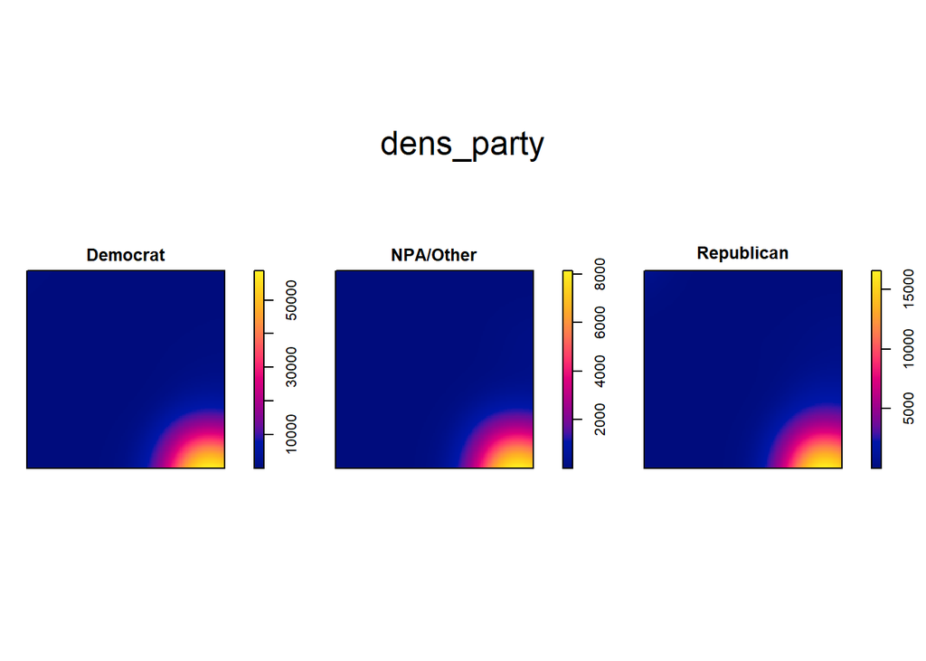

```r
dens_party <- density(party_splits)
plot(dens_party)
```

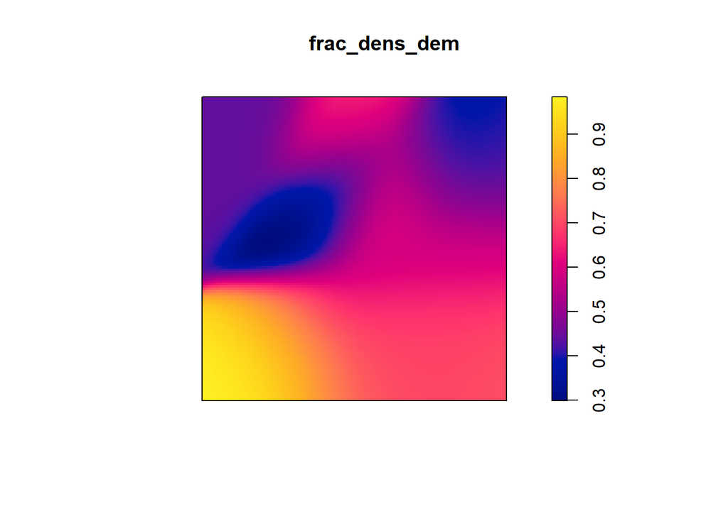

```r
frac_dens_dem <- dens_party[[1]] / (dens_party[[1]] + dens_party[[2]] + dens_party[[3]])
frac_dens_no <- dens_party[[2]] / (dens_party[[1]] + dens_party[[2]] + dens_party[[3]])
frac_dens_rep <- dens_party[[3]] / (dens_party[[1]] + dens_party[[2]] + dens_party[[3]])


plot(frac_dens_dem)
```

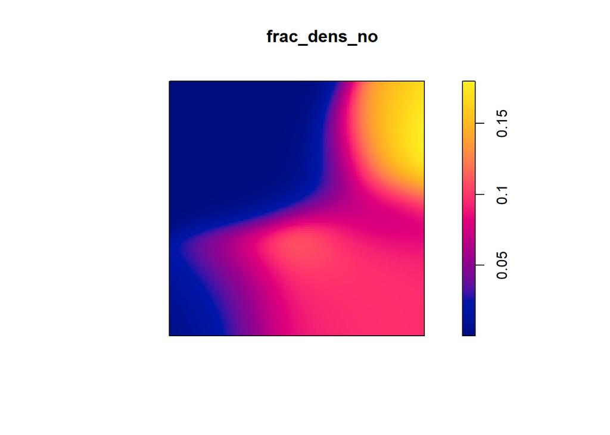

```r
plot(frac_dens_no)
```

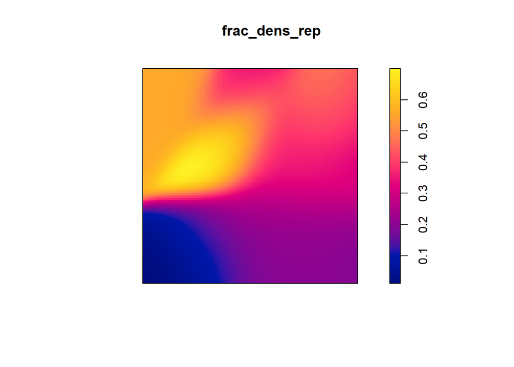

```r
plot(frac_dens_rep)
```